# What are Bollinger Bands?

`A Bollinger Band is a technical analysis tool defined by a set of lines plotted two standard deviations (positively and negatively) away from a simple moving average (SMA) of the security's price, but can be adjusted to user preferences. Bollinger Bands were developed and copyrighted by famous technical trader John Bollinger`

```
There are three lines that compose Bollinger Bands: A simple moving average (middle band) and an upper and lower band.
The upper and lower bands are typically 2 standard deviations +/- from a 20-day simple moving average, but can be modified.
```

# What Do Bollinger Bands Tell You?

`Bollinger Bands are a highly popular technique. Many traders believe the closer the prices move to the upper band, the more overbought the market, and the closer the prices move to the lower band, the more oversold the market.`

# quantopian algorithm

`This algorithm trades when the price moves 2 standard deviation away from SMA , This is a very inefficient trading strategy which can only be used as a base for many more models layered above this strategy`

def initialize(context): context.google = sid(26578)

```
schedule_function(bollinger, date_rules.every_day())
```

def bollinger(context,data):

```
google =  context.google

current_price = data.current(google,'price')

window = data.history(google, 'price', 20, '1d')
mean = window.mean()
std = window.std()
lower_band = mean - 2*std
upper_band = mean + 2*std


if current_price<= lower_band:
    order_target_percent(google,1.0)
elif current_price>= upper_band:
    order_target_percent(google, -1.0)
elif abs(current_price-mean)<.2*std:
    order_target_percent(google,0)
else:
    pass

record(upper = upper_band, lower= lower_band, moving_average = mean, google = current_price)


#  success rate of these strategies are very low, its like picking pennies in front of roller
```

# results of the algorithm

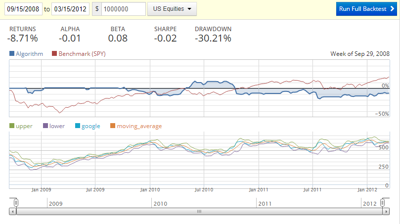

```python
from IPython.display import Image
Image(filename='image.PNG')
```

The bollinger bands above are computed from a simple moving average, they weight older price data the same as the most recent, meaning that new information may be diluted by outdated data. Also, the use of 20-day SMA and 2 standard deviations is a bit arbitrary and may not work for everyone in every situation. so we can adjust their SMA and standard deviation assumptions accordingly and monitor them.

# Why this algorithm is trading inefficient ?

```
Breakouts
Approximately 90% of price action occurs between the two bands. Any breakout above or below the bands is a major event. The breakout is not a trading signal. The mistake most people make is believing that that price hitting or exceeding one of the bands is a signal to buy or sell. Breakouts provide no clue as to the direction and extent of future price movement.
```

`When the bands come close together, constricting the moving average, it is called a squeeze. A squeeze signals a period of low volatility and is considered by traders to be a potential sign of future increased volatility and possible trading opportunities. Conversely, the wider apart the bands move, the more likely the chance of a decrease in volatility and the greater the possibility of exiting a trade. However, these conditions are not trading signals. The bands give no indication when the change may take place or which direction price could move.`

`Source: https://www.investopedia.com/terms/b/bollingerbands.asp`